# act_report

## Analysis on WeRateDogs Twitter Data

## Introduction

The Twitter account called WeRateDogs provides ratings for people's pets in exchange for a witty remark about the dog. Most of the time, ten is used as the denominator in these ratings. The numeratorts on the other hand, everytime the value is greater than ten, as shown by the numbers 11/10, as well as 12/10, 13\10, and so on. WeRateDogs has gained extensive international media coverage as a result of its more than 4 million followers. Because of Twitter's developer API, it is feasible to access information about the canines who have posted on the social media site. It is possible to combine data from a neural network system that is capable of predicting different dog breeds with Twitter JSON data to generate a highly effective combination. This huge amount of data may be acquired, analyzed, cleaned, and integrated with other data using data wrangling techniques to provide insight into the data's relationship with other data.

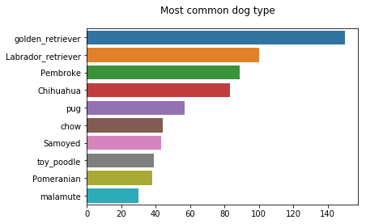

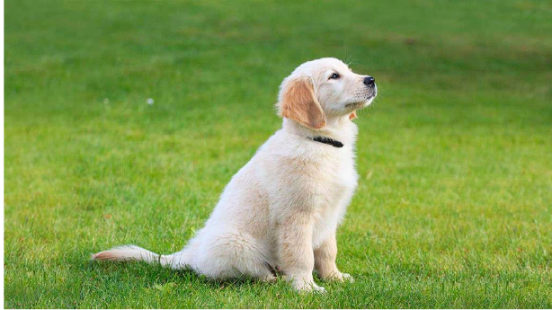

- Golden Retriever

Another issue faced with the dataset is too high values for some ratings, this is in some rare cases when the user decided to go extra mile in the rather hilarious exagerrated ratings. An example is when the long awaited rating of the Hip-hop legend Snoop Dogg was released, he got a whooping 420/10.

[figure not shown]